# Initial Exploration of the P/NBD Model

In this workbook we introduce the various different BTYD models, starting with a discussion of the underlying theory.

# 1 Background Theory

Before we start working on fitting and using the various Buy-Till-You-Die models, we first need to discuss the basic underlying theory and model.

In this model, we assume a customer becomes ‘alive’ to the business at the first purchase and then makes purchases stochastically but at a steady-rate for a period of time, and then ‘dies’ - i.e. becomes inactive to the business - hence the use of “Buy-Till-You-Die”.

Thus, at a high level these models decompose into modelling the transaction events using distributions such as the Poisson or Negative Binomial, and then modelling the ‘dropout’ process using some other method.

A number of BTYD models exist and for this workshop we will focus on the BG/NBD model - the Beta-Geometric Negative Binomial Distribution model (though we will discuss the P/NBD model also).

These models require only two pieces of information about each customer’s purchasing history: the “recency” (when the last transaction occurred) and “frequency” (the count of transactions made by that customer in a specified time period).

The notation used to represent this information is

$$X = (x, \, t_x, \, T),$$
where

From this summary data we can fit most BTYD models.

# 2 BTYD Models

There are a number of different statistical approaches to building BTYD models - relying on a number of different assumptions about how the various recency, frequency and monetary values are modelled.

We now discuss a number of different ways of modelling this.

## 2.1 Pareto/Negative-Binomial Distribution (P/NBD) Model

The P/NBD model relies on five assumptions:

1. While active, the number of transactions made by a customer follows a Poisson process with transaction rate $\lambda$.
2. Heterogeneity in $\lambda$ follows a Gamma distribution $\Gamma(\lambda \, | \, \alpha, r)$ with shape $r$ and rate $\alpha$.
3. Each customer has an unobserved ‘lifetime’ of length $\tau$. This point at which the customer becomes inactive is distributed as an exponential with dropout rate $\mu$.
4. Heterogeneity in dropout rates across customers follows a Gamma distribution $\Gamma(\mu \, | \, s, \beta)$ with shape parameter $s$ and rate parameter $\beta$.
5. The transaction rate $\lambda$ and the dropout rate $\mu$ vary independently across customers.

As before, we express this in mathematical notation as:

$$\begin{eqnarray*}
\lambda &\sim& \Gamma(\alpha, r), \\
\mu &\sim& \Gamma(s, \beta), \\
\tau &\sim& \text{Exponential}(\mu)
\end{eqnarray*}$$

## 2.2 Beta-Geometric/Negative-Binomial Distribution (BG/NBD) Model

This model relies on a number of base assumptions, somewhat similar to the P/NBD model but modelling lifetime with a different process:

1. While active, the number of transactions made by a customer follows a Poisson process with transaction rate $\lambda$.
2. Heterogeneity in $\lambda$ follows a Gamma distribution $\Gamma(\lambda \, | \, \alpha, r)$ with parameters shape $r$ and rate $\alpha$.
3. After any transaction, a customer becomes inactive with probability $p$.
4. Heterogeneity in $p$ follows a Beta distribution $B(p \, | \, a, b)$ with shape parameters $a$ and $b$.
5. The transaction rate $\lambda$ and the dropout probability $p$ vary independently across customers.

Note that it follows from the above assumptions that the probability of a customer being ‘alive’ after any transaction is given by the Geometric distribution, and hence the Beta-Geometric in the name.

To put this into more formal mathematical notation, we have:

$$\begin{eqnarray*}
\lambda &\sim& \Gamma(\alpha, r), \\
P(\text{alive}, k) &\sim& \text{Geometric}(p, k), \\
p &\sim& \text{Beta}(a, b)
\end{eqnarray*}$$

# 3 Initial P/NBD Models

We start by modelling the P/NBD model using our synthetic datasets before we try to model real-life data.

## 3.1 Load Long Time-frame Synthetic Data

```r
customer_cohortdata_tbl <- read_rds("data/synthdata_longframe_cohort_tbl.rds")
customer_cohortdata_tbl %>% glimpse()
```

```
## Rows: 50,000
## Columns: 4
## $ customer_id    <chr> "C201101_0001", "C201101_0002", "C201101_0003", "C20110…
## $ cohort_qtr     <chr> "2011 Q1", "2011 Q1", "2011 Q1", "2011 Q1", "2011 Q1", …
## $ cohort_ym      <chr> "2011 01", "2011 01", "2011 01", "2011 01", "2011 01", …
## $ first_tnx_date <date> 2011-01-01, 2011-01-01, 2011-01-01, 2011-01-01, 2011-0…
```

```r
customer_simparams_tbl  <- read_rds("data/synthdata_longframe_simparams_tbl.rds")
customer_simparams_tbl %>% glimpse()
```

```
## Rows: 50,000
## Columns: 9
## $ customer_id     <chr> "C201101_0001", "C201101_0002", "C201101_0003", "C2011…
## $ cohort_qtr      <chr> "2011 Q1", "2011 Q1", "2011 Q1", "2011 Q1", "2011 Q1",…
## $ cohort_ym       <chr> "2011 01", "2011 01", "2011 01", "2011 01", "2011 01",…
## $ first_tnx_date  <date> 2011-01-01, 2011-01-01, 2011-01-01, 2011-01-01, 2011-…
## $ customer_mu     <dbl> 0.04783829, 0.10238990, 0.03607158, 0.10886867, 0.0871…
## $ customer_tau    <dbl> 16.59526247, 3.98578810, 1.36755838, 16.12324067, 1.61…
## $ customer_lambda <dbl> 0.37963949, 0.08399882, 0.27328828, 0.32830425, 0.0561…
## $ customer_nu     <dbl> 1.704865659, 0.162742489, 0.874737616, 1.005165071, 0.…
## $ customer_p      <dbl> 100, 100, 100, 100, 100, 100, 100, 100, 100, 100, 100,…
```

```r
customer_transactions_tbl <- read_rds("data/synthdata_longframe_transactions_tbl.rds")
customer_transactions_tbl %>% glimpse()
```

```
## Rows: 269,702
## Columns: 4
## $ customer_id   <chr> "C201101_0002", "C201101_0018", "C201101_0001", "C201101…
## $ tnx_timestamp <dttm> 2011-01-01 00:20:28, 2011-01-01 00:43:10, 2011-01-01 02…
## $ invoice_id    <chr> "T20110101-0001", "T20110101-0002", "T20110101-0003", "T…
## $ tnx_amount    <dbl> 547.93, 90.67, 57.90, 143.08, 113.37, 22.20, 574.21, 112…
```

## 3.2 Derive the Log-likelihood Function

We now turn our attention to deriving the log-likelihood model for the P/NBD model.

We assume that we know that a given customer has made $x$ transactions after the initial one over an observed period of time $T$, and we label these transactions $t_1$, $t_2$, …, $t_x$.

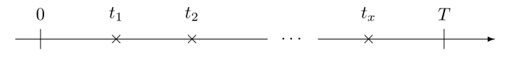

To model the likelihood for this observation, we need to consider two possibilities: one for where the customer is still ‘alive’ at $T$, and one where the customer has ‘died’ by $T$.

In the first instance, the likelihood is the product of the observations of each transaction, multiplied by the likelihood of the customer still being alive at time $T$.

Because we are modelling the transaction counts as a Poisson process, this corresponds to the times between events following an exponential distribution, and so both the transaction times and the lifetime likelihoods use the exponential.

This gives us:

$$\begin{eqnarray*}
L(\lambda \, | \, t_1, t_2, ..., t_x, T, \, \tau > T)
&=& \lambda e^{-\lambda t_1} \lambda e^{-\lambda(t_2 - t_1)} ...
\lambda e^{-\lambda (t_x - t_{x-1})} e^{-\lambda(T - t)} \\
&=& \lambda^x e^{-\lambda T}
\end{eqnarray*}$$

and we can combine this with the likelihood of the lifetime of the customer $\tau$ being greater than the observation window $T$,

$$P(\tau > T \, | \, \mu) = e^{-\mu T}$$

For the second case, the customer becomes inactive at some time $\tau$ in the interval $(t_x, T]$, and so the likelihood is

$$\begin{eqnarray*}
L(\lambda \, | \, t_1, t_2, ..., t_x, T, \, \tau > T)
&=& \lambda e^{-\lambda t_1} \lambda e^{-\lambda(t_2 - t_1)} ...
\lambda e^{-\lambda (t_x - t_{x-1})} e^{-\lambda(\tau - t_x)} \\
&=& \lambda^x e^{-\lambda \tau}
\end{eqnarray*}$$

In both cases we do not need the times of the individual transactions, and all we need are the values $(x, t_x, T)$.

As we cannot observe $\tau$, we want to remove the conditioning on $\tau$ by integrating it out.

$$\begin{eqnarray*}
L(\lambda, \mu \, | \, x, t_x, T)
&=& L(\lambda \, | \, t_1, t_2, ..., t_x, T, \, \tau > T) \, P(\tau > T \, | \, \mu) +
\int^T_{t_x} L(\lambda \, | \, x, T, \text{ inactive at } (t_x, T] ) \, f(\tau \, | \mu) d\tau \\
&=& \lambda^x e^{-\lambda T} e^{\mu T} +
\lambda^x \int^T_{t_x} e^{-\lambda \tau} \mu e^{-\mu \tau} d\tau \\
&=& \lambda^x e^{-(\lambda + \mu)T} + \frac{\lambda^x \mu}{\lambda + \mu} e^{-(\lambda + \mu) t_x} +
\frac{\lambda^x \mu}{\lambda + \mu} e^{-(\lambda + \mu) T} \\
&=& \frac{\lambda^x \mu}{\lambda + \mu} e^{-(\lambda + \mu) t_x} +
\frac{\lambda^{x+1} \mu}{\lambda + \mu} e^{-(\lambda + \mu) T}
\end{eqnarray*}$$

In Stan, we do not calculate the likelihoods but the Log-likelihood, so we need to take the log of this expression. This creates a problem, as we have no easy way to calculate $\log(a + b)$. As this expression occurs a lot, Stan provides a `log_sum_exp()`, which is defined by

$$\log \, (a + b) = \text{log_sum_exp}(\log a, \log b)$$

$$\begin{eqnarray*}
LL(\lambda, \mu \, | \, x, t_x, T)
&=&
\log \left(
\frac{\lambda^x \, \mu}{\lambda + \mu}
\left( e^{-(\lambda + \mu) t_x} + \lambda e^{-(\lambda + \mu) T} \right)
\right) \\
&=& x \log \lambda + \log \mu -log(\lambda + \mu) +
\text{log_sum_exp}(-(\lambda + \mu) \, t_x, \; \log \lambda - (\lambda + \mu) \, T)
\end{eqnarray*}$$

This is the log-likelihood model we want to fit in Stan.

## 3.3 Construct Datasets

```r
customer_summarystats_tbl <- customer_transactions_tbl %>%
  calculate_transaction_cbs_data(last_date = as.Date("2018-12-31"))

customer_summarystats_tbl %>% glimpse()
```

```
## Rows: 44,306
## Columns: 6
## $ customer_id    <chr> "C201101_0001", "C201101_0002", "C201101_0003", "C20110…
## $ first_tnx_date <dttm> 2011-01-01 02:19:57, 2011-01-01 00:20:28, 2011-01-01 1…
## $ last_tnx_date  <dttm> 2011-03-15 15:59:06, 2011-01-20 08:47:25, 2011-01-01 1…
## $ x              <dbl> 6, 1, 0, 4, 0, 3, 0, 2, 5, 3, 1, 1, 23, 0, 1, 2, 1, 22,…
## $ t_x            <dbl> 10.5098368, 2.7645783, 0.0000000, 11.2458596, 0.0000000…
## $ T_cal          <dbl> 417.2718, 417.2837, 417.2001, 417.2551, 417.1894, 417.1…
```

As before, we construct a number of subsets of the data for use later on with the modelling and create some data subsets.

```r
shuffle_tbl <- customer_summarystats_tbl %>%
  slice_sample(n = nrow(.), replace = FALSE)

id_1000  <- shuffle_tbl %>% head(1000)  %>% pull(customer_id) %>% sort()
id_5000  <- shuffle_tbl %>% head(5000)  %>% pull(customer_id) %>% sort()
id_10000 <- shuffle_tbl %>% head(10000) %>% pull(customer_id) %>% sort()
```

We then construct some fit data based on these values.

```r
fit_1000_data_tbl  <- customer_summarystats_tbl %>% filter(customer_id %in% id_1000)
fit_1000_data_tbl %>% glimpse()
```

```
## Rows: 1,000
## Columns: 6
## $ customer_id    <chr> "C201101_0016", "C201101_0027", "C201101_0094", "C20110…
## $ first_tnx_date <dttm> 2011-01-01 19:05:19, 2011-01-02 05:24:02, 2011-01-07 1…
## $ last_tnx_date  <dttm> 2011-02-22 03:23:40, 2011-01-16 23:53:21, 2011-11-17 0…
## $ x              <dbl> 2, 1, 21, 2, 1, 0, 10, 0, 9, 1, 10, 0, 0, 4, 2, 0, 0, 6…
## $ t_x            <dbl> 7.3351542, 2.1100510, 44.8150321, 1.4532005, 11.6351693…
## $ T_cal          <dbl> 417.1721, 417.1107, 416.3276, 416.2101, 416.2779, 415.7…
```

```r
fit_10000_data_tbl <- customer_summarystats_tbl %>% filter(customer_id %in% id_10000)
fit_10000_data_tbl %>% glimpse()
```

```
## Rows: 10,000
## Columns: 6
## $ customer_id    <chr> "C201101_0001", "C201101_0004", "C201101_0006", "C20110…
## $ first_tnx_date <dttm> 2011-01-01 02:19:57, 2011-01-01 05:08:08, 2011-01-01 1…
## $ last_tnx_date  <dttm> 2011-03-15 15:59:06, 2011-03-20 22:26:24, 2011-03-11 0…
## $ x              <dbl> 6, 4, 3, 2, 0, 0, 1, 0, 5, 0, 2, 2, 1, 1, 0, 0, 3, 0, 0…
## $ t_x            <dbl> 10.509837, 11.245860, 9.823987, 7.335154, 0.000000, 0.0…
## $ T_cal          <dbl> 417.2718, 417.2551, 417.1934, 417.1721, 417.0649, 417.0…
```

# 4 Fit Initial P/NBD Model

We now construct our Stan model and prepare to fit it with our synthetic dataset.

Before we start on that, we set a few parameters for the workbook to organise our Stan code.

```r
stan_modeldir <- "stan_models"
stan_codedir  <-   "stan_code"
```

We start with the Stan model.

```
## functions {
##   #include util_functions.stan
## }
##
## data {
##   int<lower=1> n;           // number of customers
##
##   vector<lower=0>[n] t_x;   // time to most recent purchase
##   vector<lower=0>[n] T_cal; // total observation time
##   vector<lower=0>[n] x;     // number of purchases observed
##
##   real<lower=0> lambda_mn;  // hyperprior mean for lambda
##   real<lower=0> lambda_cv;  // hyperprior cv   for lambda
##
##   real<lower=0> mu_mn;      // hyperprior mean for mu
##   real<lower=0> mu_cv;      // hyperprior mean for mu
## }
##
## transformed data {
##   real<lower=0> r     = 1 / (lambda_cv * lambda_cv);
##   real<lower=0> alpha = 1 / (lambda_cv * lambda_cv * lambda_mn);
##
##   real<lower=0> s    = 1 / (mu_cv * mu_cv);
##   real<lower=0> beta = 1 / (mu_cv * mu_cv * mu_mn);
## }
##
##
## parameters {
##   vector<lower=0>[n] lambda; // purchase rate
##   vector<lower=0>[n] mu;     // lifetime dropout rate
## }
##
##
## model {
##   // setting priors
##   lambda ~ gamma(r, alpha);
##   mu     ~ gamma(s,  beta);
##
##   target += calculate_pnbd_loglik(n, lambda, mu, x, t_x, T_cal);
## }
```

This file contains a few new features of Stan - named file includes and user-defined functions - `calculate_pnbd_loglik`. We look at this file here:

```
## real calculate_pnbd_loglik(int n, vector lambda, vector mu,
##                            data vector x, data vector t_x, data vector T_cal) {
##   // likelihood
##   vector[n] t1;
##   vector[n] t2;
##
##   vector[n] lpm;
##   vector[n] lht;
##   vector[n] rht;
##
##   lpm = lambda + mu;
##
##   lht = log(lambda) - lpm .* T_cal;
##   rht = log(mu)     - lpm .* t_x;
##
##   t1  = x .* log(lambda) - log(lpm);
##
##   for (i in 1:n) {
##     t2[i] = log_sum_exp(lht[i], rht[i]);
##   }
##
##   return(sum(t1) + sum(t2));
## }
##
##
## real calculate_bgnbd_loglik(int n, vector lambda, vector p,
##                             data vector x, data vector t_x, data vector T_cal) {
##   // likelihood
##   vector[n] t1;
##   vector[n] t2;
##
##   vector[n] lht;
##   vector[n] rht;
##
##   lht = log(p) + (x-1) .* log(1-p) + x .* log(lambda) - lambda .* t_x;
##   rht = x .* log(1-p) + x .* log(lambda) - lambda .* T_cal;
##
##   for(i in 1:n) {
##     t2[i] = log_sum_exp(lht[i], rht[i]);
##   }
##
##   return(sum(t2));
## }
```

We now compile this model using `CmdStanR`.

```r
pnbd_fixed_stanmodel <- cmdstan_model(
  "stan_code/pnbd_fixed.stan",
  include_paths =   stan_codedir,
  pedantic      =           TRUE,
  dir           =  stan_modeldir
  )
```

We then use this compiled model with our data to produce a fit of the data.

```r
stan_modelname <- "pnbd_fixed"
stanfit_prefix <- str_c("fit_", stan_modelname)

stan_data_lst <- fit_1000_data_tbl %>%
  select(customer_id, x, t_x, T_cal) %>%
  compose_data(
    lambda_mn = 0.25,
    lambda_cv = 1.00,

    mu_mn     = 0.10,
    mu_cv     = 1.00,
    )

pnbd_fixed_stanfit <- pnbd_fixed_stanmodel$sample(
  data            =                stan_data_lst,
  chains          =                            4,
  iter_warmup     =                          500,
  iter_sampling   =                          500,
  seed            =                         4201,
  save_warmup     =                         TRUE,
  output_dir      =                stan_modeldir,
  output_basename =               stanfit_prefix,
  )
```

```
## Running MCMC with 4 parallel chains...
##
## Chain 1 Iteration:   1 / 1000 [  0%]  (Warmup)
## Chain 2 Iteration:   1 / 1000 [  0%]  (Warmup)
## Chain 3 Iteration:   1 / 1000 [  0%]  (Warmup)
## Chain 4 Iteration:   1 / 1000 [  0%]  (Warmup)
## Chain 1 Iteration: 100 / 1000 [ 10%]  (Warmup)
## Chain 2 Iteration: 100 / 1000 [ 10%]  (Warmup)
## Chain 4 Iteration: 100 / 1000 [ 10%]  (Warmup)
## Chain 3 Iteration: 100 / 1000 [ 10%]  (Warmup)
## Chain 1 Iteration: 200 / 1000 [ 20%]  (Warmup)
## Chain 2 Iteration: 200 / 1000 [ 20%]  (Warmup)
## Chain 4 Iteration: 200 / 1000 [ 20%]  (Warmup)
## Chain 3 Iteration: 200 / 1000 [ 20%]  (Warmup)
## Chain 1 Iteration: 300 / 1000 [ 30%]  (Warmup)
## Chain 2 Iteration: 300 / 1000 [ 30%]  (Warmup)
## Chain 3 Iteration: 300 / 1000 [ 30%]  (Warmup)
## Chain 4 Iteration: 300 / 1000 [ 30%]  (Warmup)
## Chain 1 Iteration: 400 / 1000 [ 40%]  (Warmup)
## Chain 3 Iteration: 400 / 1000 [ 40%]  (Warmup)
## Chain 4 Iteration: 400 / 1000 [ 40%]  (Warmup)
## Chain 2 Iteration: 400 / 1000 [ 40%]  (Warmup)
## Chain 1 Iteration: 500 / 1000 [ 50%]  (Warmup)
## Chain 1 Iteration: 501 / 1000 [ 50%]  (Sampling)
## Chain 3 Iteration: 500 / 1000 [ 50%]  (Warmup)
## Chain 3 Iteration: 501 / 1000 [ 50%]  (Sampling)
## Chain 4 Iteration: 500 / 1000 [ 50%]  (Warmup)
## Chain 4 Iteration: 501 / 1000 [ 50%]  (Sampling)
## Chain 2 Iteration: 500 / 1000 [ 50%]  (Warmup)
## Chain 2 Iteration: 501 / 1000 [ 50%]  (Sampling)
## Chain 1 Iteration: 600 / 1000 [ 60%]  (Sampling)
## Chain 3 Iteration: 600 / 1000 [ 60%]  (Sampling)
## Chain 4 Iteration: 600 / 1000 [ 60%]  (Sampling)
## Chain 2 Iteration: 600 / 1000 [ 60%]  (Sampling)
## Chain 1 Iteration: 700 / 1000 [ 70%]  (Sampling)
## Chain 3 Iteration: 700 / 1000 [ 70%]  (Sampling)
## Chain 4 Iteration: 700 / 1000 [ 70%]  (Sampling)
## Chain 2 Iteration: 700 / 1000 [ 70%]  (Sampling)
## Chain 1 Iteration: 800 / 1000 [ 80%]  (Sampling)
## Chain 3 Iteration: 800 / 1000 [ 80%]  (Sampling)
## Chain 4 Iteration: 800 / 1000 [ 80%]  (Sampling)
## Chain 2 Iteration: 800 / 1000 [ 80%]  (Sampling)
## Chain 1 Iteration: 900 / 1000 [ 90%]  (Sampling)
## Chain 3 Iteration: 900 / 1000 [ 90%]  (Sampling)
## Chain 4 Iteration: 900 / 1000 [ 90%]  (Sampling)
## Chain 2 Iteration: 900 / 1000 [ 90%]  (Sampling)
## Chain 1 Iteration: 1000 / 1000 [100%]  (Sampling)
## Chain 1 finished in 19.2 seconds.
## Chain 3 Iteration: 1000 / 1000 [100%]  (Sampling)
## Chain 3 finished in 19.5 seconds.
## Chain 4 Iteration: 1000 / 1000 [100%]  (Sampling)
## Chain 4 finished in 19.6 seconds.
## Chain 2 Iteration: 1000 / 1000 [100%]  (Sampling)
## Chain 2 finished in 19.9 seconds.
##
## All 4 chains finished successfully.
## Mean chain execution time: 19.5 seconds.
## Total execution time: 20.1 seconds.
```

```r
pnbd_fixed_stanfit$summary()
```

```
## # A tibble: 2,001 × 10
##    variable       mean   median      sd     mad       q5      q95  rhat ess_bulk
##    <chr>         <dbl>    <dbl>   <dbl>   <dbl>    <dbl>    <dbl> <dbl>    <dbl>
##  1 lp__       -1.65e+4 -1.65e+4 35.0    34.7    -1.66e+4 -1.64e+4  1.00     678.
##  2 lambda[1]   2.08e-1  1.80e-1  0.131   0.115   5.10e-2  4.53e-1  1.00    3502.
##  3 lambda[2]   2.29e-1  1.80e-1  0.181   0.146   3.41e-2  5.98e-1  1.00    3777.
##  4 lambda[3]   4.32e-1  4.26e-1  0.0970  0.0955  2.88e-1  6.06e-1  1.01    5451.
##  5 lambda[4]   4.25e-1  3.62e-1  0.276   0.244   9.65e-2  9.55e-1  1.00    2908.
##  6 lambda[5]   9.22e-2  7.32e-2  0.0719  0.0577  1.48e-2  2.34e-1  1.01    3817.
##  7 lambda[6]   1.41e-1  8.21e-2  0.167   0.0913  4.39e-3  4.72e-1  1.00    2803.
##  8 lambda[7]   1.23e+0  1.19e+0  0.388   0.369   6.52e-1  1.94e+0  1.01    4995.
##  9 lambda[8]   1.42e-1  8.69e-2  0.161   0.0975  5.40e-3  4.74e-1  1.00    3209.
## 10 lambda[9]   5.17e-1  4.97e-1  0.167   0.160   2.80e-1  8.26e-1  1.00    4633.
## # … with 1,991 more rows, and 1 more variable: ess_tail <dbl>
```

We have some basic HMC-based validity statistics we can check.

```r
pnbd_fixed_stanfit$cmdstan_diagnose()
```

```
## Processing csv files: /home/rstudio/workshop/stan_models/fit_pnbd_fixed-1.csvWarning: non-fatal error reading adaptation data
## , /home/rstudio/workshop/stan_models/fit_pnbd_fixed-2.csvWarning: non-fatal error reading adaptation data
## , /home/rstudio/workshop/stan_models/fit_pnbd_fixed-3.csvWarning: non-fatal error reading adaptation data
## , /home/rstudio/workshop/stan_models/fit_pnbd_fixed-4.csvWarning: non-fatal error reading adaptation data
##
##
## Checking sampler transitions treedepth.
## Treedepth satisfactory for all transitions.
##
## Checking sampler transitions for divergences.
## No divergent transitions found.
##
## Checking E-BFMI - sampler transitions HMC potential energy.
## E-BFMI satisfactory.
##
## Effective sample size satisfactory.
##
## Split R-hat values satisfactory all parameters.
##
## Processing complete, no problems detected.
```

## 4.1 Visual Diagnostics of the Sample Validity

Now that we have a sample from the posterior distribution we need to create a few different visualisations of the diagnostics.

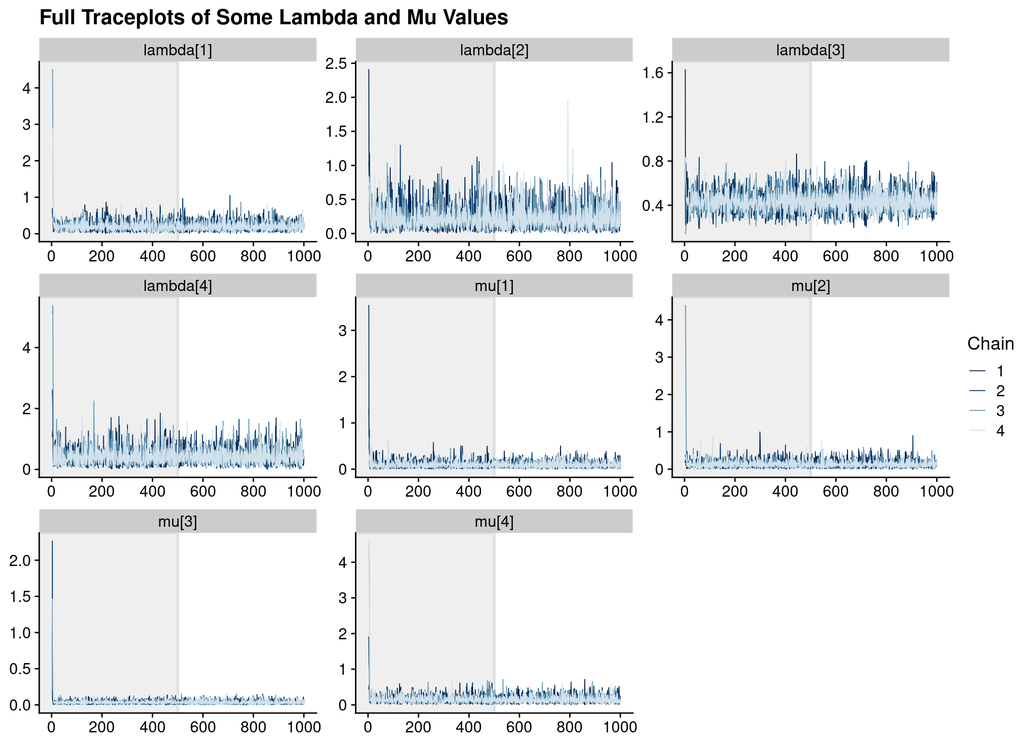

```r
parameter_subset <- c(
  "lambda[1]", "lambda[2]", "lambda[3]", "lambda[4]",
  "mu[1]",     "mu[2]",     "mu[3]",     "mu[4]"
  )

pnbd_fixed_stanfit$draws(inc_warmup = TRUE) %>%
  mcmc_trace(
    pars     = parameter_subset,
    n_warmup = 500
    ) +
  ggtitle("Full Traceplots of Some Lambda and Mu Values")
```

As the warmup is skewing the y-axis somewhat, we repeat this process without the warmup.

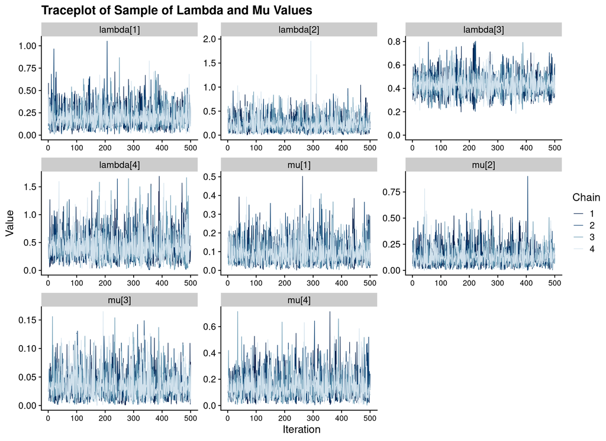

```r
pnbd_fixed_stanfit$draws(inc_warmup = FALSE) %>%
  mcmc_trace(pars = parameter_subset) +
  expand_limits(y = 0) +
  labs(
    x = "Iteration",
    y = "Value",
    title = "Traceplot of Sample of Lambda and Mu Values"
    ) +
  theme(axis.text.x = element_text(size = 10))
```

A common MCMC diagnostic is $\hat{R}$ - which is a measure of the ‘similarity’ of the chains.

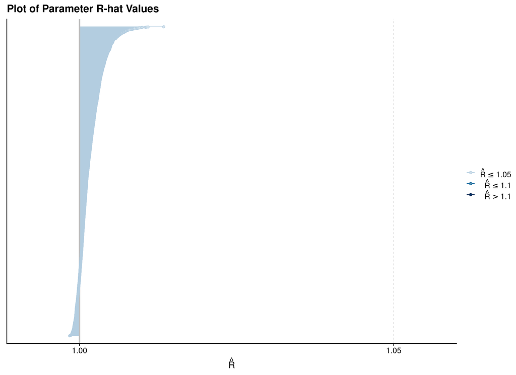

```r
pnbd_fixed_stanfit %>%
  rhat(pars = c("lambda", "mu")) %>%
  mcmc_rhat() +
    ggtitle("Plot of Parameter R-hat Values")
```

Related to this quantity is the concept of *effective sample size*, $N_{eff}$, an estimate of the size of the sample from a statistical information point of view.

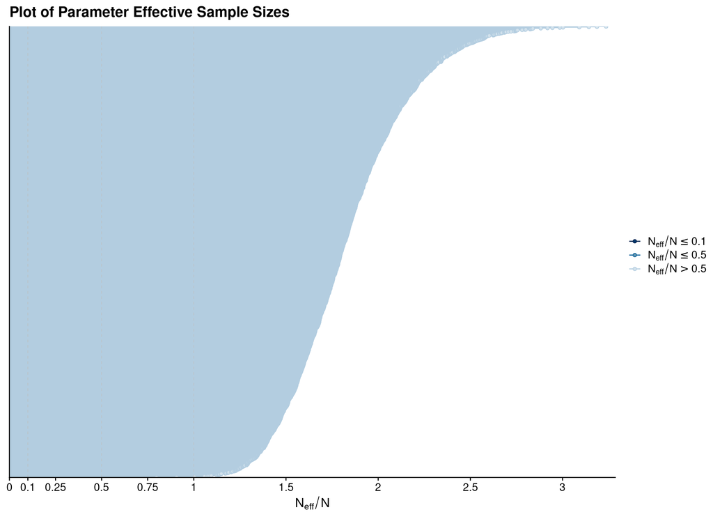

```r
pnbd_fixed_stanfit %>%
  neff_ratio(pars = c("lambda", "mu")) %>%
  mcmc_neff() +
    ggtitle("Plot of Parameter Effective Sample Sizes")
```

Finally, we also want to look at autocorrelation in the chains for each parameter.

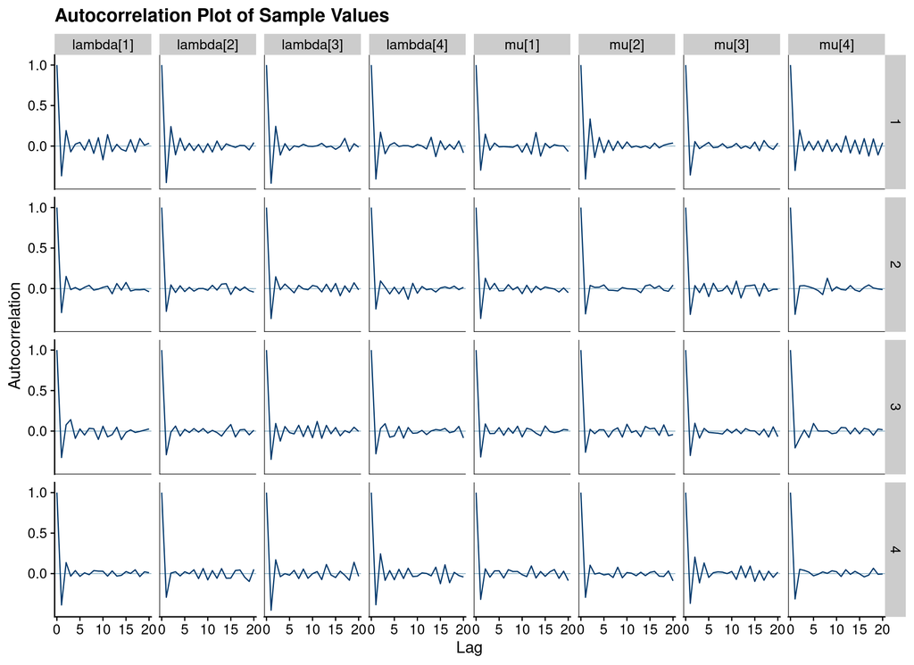

```r
pnbd_fixed_stanfit$draws() %>%
  mcmc_acf(pars = parameter_subset) +
    ggtitle("Autocorrelation Plot of Sample Values")
```

## 4.2 Check Model Fit

As we are still working with synthetic data, we know the true values for each customer and so we can check how good our model is at recovering the true values on a customer-by-customer basis.

As in previous workbooks, we build our validation datasets and then check the distribution of $q$-values for both $\lambda$ and $\mu$ across the customer base.

```r
pnbd_fixed_valid_lst <- create_posterior_validation_data(
  stanfit       = pnbd_fixed_stanfit,
  data_tbl      = fit_1000_data_tbl,
  simparams_tbl = customer_simparams_tbl
  )
```

```
## Rows: 2,000,000
## Columns: 6
## $ customer_id     <chr> "C201101_0016", "C201101_0016", "C201101_0016", "C2011…
## $ draw_id         <int> 1, 2, 3, 4, 5, 6, 7, 8, 9, 10, 11, 12, 13, 14, 15, 16,…
## $ post_lambda     <dbl> 0.5839180, 0.1094220, 0.2547100, 0.1878440, 0.1306650,…
## $ customer_lambda <dbl> 0.06427873, 0.06427873, 0.06427873, 0.06427873, 0.0642…
## $ post_mu         <dbl> 0.1755520, 0.0735625, 0.0572432, 0.1038250, 0.0742492,…
## $ customer_mu     <dbl> 0.05554531, 0.05554531, 0.05554531, 0.05554531, 0.0555…
```

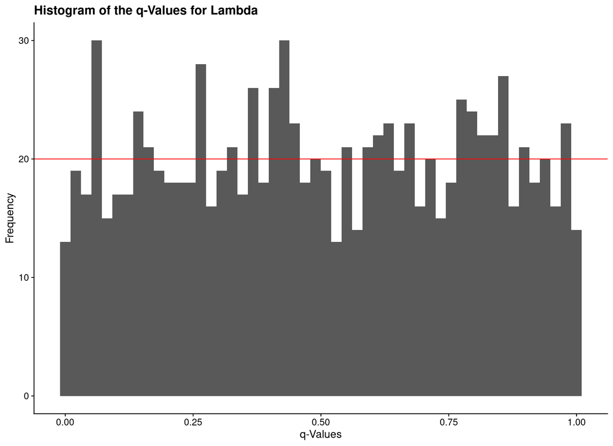

```r
pnbd_fixed_valid_lst$lambda_qval_plot %>% plot()
```

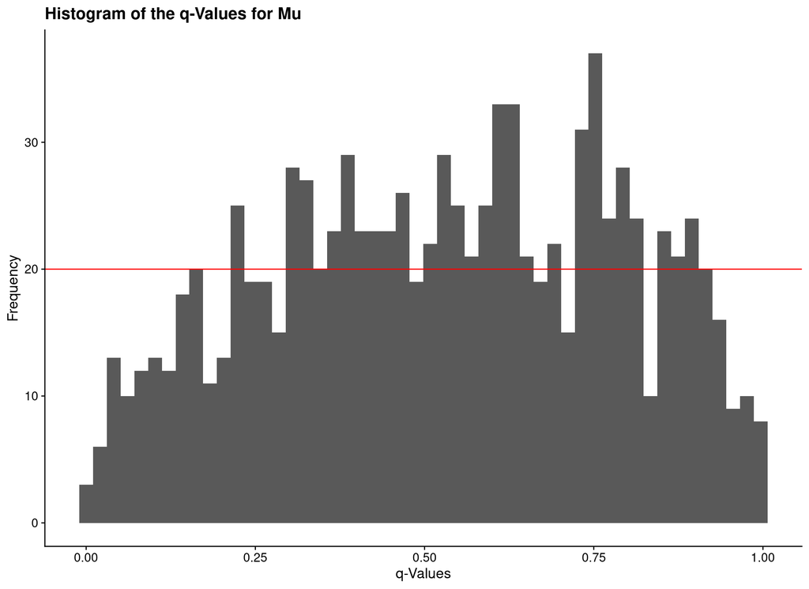

```r
pnbd_fixed_valid_lst$mu_qval_plot %>% plot()
```

# 5 Fit Alternate Prior P/NBD Model

We now repeat all of the above but with an alternative set of priors and compare the outputs to give us an idea of the sensitivity of the inference to the input priors.

We will repeat this a few times, so we start by increasing the co-efficient of variation in the priors. We keep everything else constant, including the seed used by Stan.

```r
stan_modelname <- "pnbd_fixed2"
stanfit_prefix <- str_c("fit_", stan_modelname)

stan_data_lst <- fit_1000_data_tbl %>%
  select(customer_id, x, t_x, T_cal) %>%
  compose_data(
    lambda_mn = 0.25,
    lambda_cv = 2.00,

    mu_mn     = 0.10,
    mu_cv     = 2.00,
    )

pnbd_fixed2_stanfit <- pnbd_fixed_stanmodel$sample(
  data            =                stan_data_lst,
  chains          =                            4,
  iter_warmup     =                          500,
  iter_sampling   =                          500,
  seed            =                         4201,
  save_warmup     =                         TRUE,
  output_dir      =                stan_modeldir,
  output_basename =               stanfit_prefix,
  )
```

```
## Running MCMC with 4 parallel chains...
##
## Chain 1 Iteration:   1 / 1000 [  0%]  (Warmup)
## Chain 2 Iteration:   1 / 1000 [  0%]  (Warmup)
## Chain 3 Iteration:   1 / 1000 [  0%]  (Warmup)
## Chain 4 Iteration:   1 / 1000 [  0%]  (Warmup)
## Chain 2 Iteration: 100 / 1000 [ 10%]  (Warmup)
## Chain 4 Iteration: 100 / 1000 [ 10%]  (Warmup)
## Chain 1 Iteration: 100 / 1000 [ 10%]  (Warmup)
## Chain 3 Iteration: 100 / 1000 [ 10%]  (Warmup)
## Chain 2 Iteration: 200 / 1000 [ 20%]  (Warmup)
## Chain 4 Iteration: 200 / 1000 [ 20%]  (Warmup)
## Chain 3 Iteration: 200 / 1000 [ 20%]  (Warmup)
## Chain 1 Iteration: 200 / 1000 [ 20%]  (Warmup)
## Chain 2 Iteration: 300 / 1000 [ 30%]  (Warmup)
## Chain 4 Iteration: 300 / 1000 [ 30%]  (Warmup)
## Chain 3 Iteration: 300 / 1000 [ 30%]  (Warmup)
## Chain 1 Iteration: 300 / 1000 [ 30%]  (Warmup)
## Chain 4 Iteration: 400 / 1000 [ 40%]  (Warmup)
## Chain 2 Iteration: 400 / 1000 [ 40%]  (Warmup)
## Chain 3 Iteration: 400 / 1000 [ 40%]  (Warmup)
## Chain 1 Iteration: 400 / 1000 [ 40%]  (Warmup)
## Chain 2 Iteration: 500 / 1000 [ 50%]  (Warmup)
## Chain 4 Iteration: 500 / 1000 [ 50%]  (Warmup)
## Chain 4 Iteration: 501 / 1000 [ 50%]  (Sampling)
## Chain 2 Iteration: 501 / 1000 [ 50%]  (Sampling)
## Chain 3 Iteration: 500 / 1000 [ 50%]  (Warmup)
## Chain 3 Iteration: 501 / 1000 [ 50%]  (Sampling)
## Chain 1 Iteration: 500 / 1000 [ 50%]  (Warmup)
## Chain 1 Iteration: 501 / 1000 [ 50%]  (Sampling)
## Chain 4 Iteration: 600 / 1000 [ 60%]  (Sampling)
## Chain 2 Iteration: 600 / 1000 [ 60%]  (Sampling)
## Chain 3 Iteration: 600 / 1000 [ 60%]  (Sampling)
## Chain 1 Iteration: 600 / 1000 [ 60%]  (Sampling)
## Chain 4 Iteration: 700 / 1000 [ 70%]  (Sampling)
## Chain 2 Iteration: 700 / 1000 [ 70%]  (Sampling)
## Chain 3 Iteration: 700 / 1000 [ 70%]  (Sampling)
## Chain 1 Iteration: 700 / 1000 [ 70%]  (Sampling)
## Chain 4 Iteration: 800 / 1000 [ 80%]  (Sampling)
## Chain 2 Iteration: 800 / 1000 [ 80%]  (Sampling)
## Chain 3 Iteration: 800 / 1000 [ 80%]  (Sampling)
## Chain 1 Iteration: 800 / 1000 [ 80%]  (Sampling)
## Chain 4 Iteration: 900 / 1000 [ 90%]  (Sampling)
## Chain 2 Iteration: 900 / 1000 [ 90%]  (Sampling)
## Chain 3 Iteration: 900 / 1000 [ 90%]  (Sampling)
## Chain 1 Iteration: 900 / 1000 [ 90%]  (Sampling)
## Chain 4 Iteration: 1000 / 1000 [100%]  (Sampling)
## Chain 4 finished in 46.5 seconds.
## Chain 2 Iteration: 1000 / 1000 [100%]  (Sampling)
## Chain 2 finished in 46.9 seconds.
## Chain 3 Iteration: 1000 / 1000 [100%]  (Sampling)
## Chain 3 finished in 47.0 seconds.
## Chain 1 Iteration: 1000 / 1000 [100%]  (Sampling)
## Chain 1 finished in 48.9 seconds.
##
## All 4 chains finished successfully.
## Mean chain execution time: 47.3 seconds.
## Total execution time: 49.1 seconds.
```

```r
pnbd_fixed_stanfit$summary()
```

```
## # A tibble: 2,001 × 10
##    variable       mean   median      sd     mad       q5      q95  rhat ess_bulk
##    <chr>         <dbl>    <dbl>   <dbl>   <dbl>    <dbl>    <dbl> <dbl>    <dbl>
##  1 lp__       -1.65e+4 -1.65e+4 35.0    34.7    -1.66e+4 -1.64e+4  1.00     678.
##  2 lambda[1]   2.08e-1  1.80e-1  0.131   0.115   5.10e-2  4.53e-1  1.00    3502.
##  3 lambda[2]   2.29e-1  1.80e-1  0.181   0.146   3.41e-2  5.98e-1  1.00    3777.
##  4 lambda[3]   4.32e-1  4.26e-1  0.0970  0.0955  2.88e-1  6.06e-1  1.01    5451.
##  5 lambda[4]   4.25e-1  3.62e-1  0.276   0.244   9.65e-2  9.55e-1  1.00    2908.
##  6 lambda[5]   9.22e-2  7.32e-2  0.0719  0.0577  1.48e-2  2.34e-1  1.01    3817.
##  7 lambda[6]   1.41e-1  8.21e-2  0.167   0.0913  4.39e-3  4.72e-1  1.00    2803.
##  8 lambda[7]   1.23e+0  1.19e+0  0.388   0.369   6.52e-1  1.94e+0  1.01    4995.
##  9 lambda[8]   1.42e-1  8.69e-2  0.161   0.0975  5.40e-3  4.74e-1  1.00    3209.
## 10 lambda[9]   5.17e-1  4.97e-1  0.167   0.160   2.80e-1  8.26e-1  1.00    4633.
## # … with 1,991 more rows, and 1 more variable: ess_tail <dbl>
```

We have some basic HMC-based validity statistics we can check.

```r
pnbd_fixed2_stanfit$cmdstan_diagnose()
```

```
## Processing csv files: /home/rstudio/workshop/stan_models/fit_pnbd_fixed2-1.csvWarning: non-fatal error reading adaptation data
## , /home/rstudio/workshop/stan_models/fit_pnbd_fixed2-2.csvWarning: non-fatal error reading adaptation data
## , /home/rstudio/workshop/stan_models/fit_pnbd_fixed2-3.csvWarning: non-fatal error reading adaptation data
## , /home/rstudio/workshop/stan_models/fit_pnbd_fixed2-4.csvWarning: non-fatal error reading adaptation data
##
##
## Checking sampler transitions treedepth.
## Treedepth satisfactory for all transitions.
##
## Checking sampler transitions for divergences.
## No divergent transitions found.
##
## Checking E-BFMI - sampler transitions HMC potential energy.
## E-BFMI satisfactory.
##
## Effective sample size satisfactory.
##
## Split R-hat values satisfactory all parameters.
##
## Processing complete, no problems detected.
```

## 5.1 Visual Diagnostics of the Sample Validity

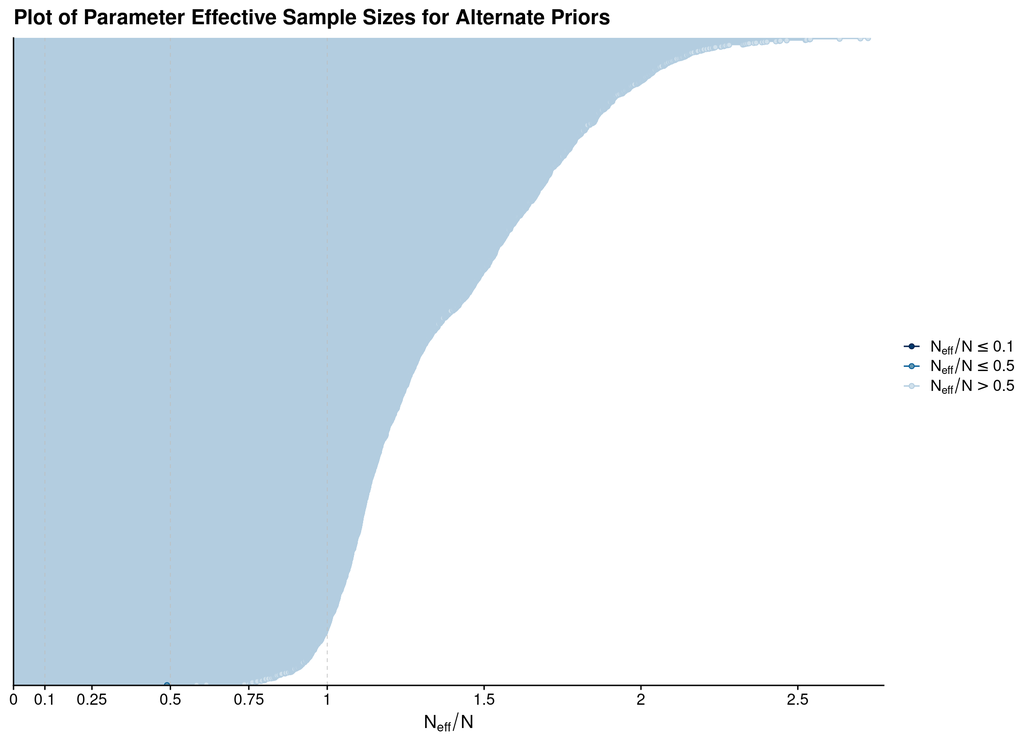

```r
pnbd_fixed2_stanfit %>%
  neff_ratio(pars = c("lambda", "mu")) %>%
  mcmc_neff() +
    ggtitle("Plot of Parameter Effective Sample Sizes for Alternate Priors")
```

## 5.2 Check Model Fit

As we are still working with synthetic data, we know the true values for each customer and so we can check how good our model is at recovering the true values on a customer-by-customer basis.

As in previous workbooks, we build our validation datasets and then check the distribution of $q$-values for both $\lambda$ and $\mu$ across the customer base.

```r
pnbd_fixed2_valid_lst <- create_posterior_validation_data(
  stanfit       = pnbd_fixed2_stanfit,
  data_tbl      = fit_1000_data_tbl,
  simparams_tbl = customer_simparams_tbl
  )
```

```
## Rows: 2,000,000
## Columns: 6
## $ customer_id     <chr> "C201101_0016", "C201101_0016", "C201101_0016", "C2011…
## $ draw_id         <int> 1, 2, 3, 4, 5, 6, 7, 8, 9, 10, 11, 12, 13, 14, 15, 16,…
## $ post_lambda     <dbl> 0.12030000, 0.58938600, 0.23790400, 0.25025700, 0.1910…
## $ customer_lambda <dbl> 0.06427873, 0.06427873, 0.06427873, 0.06427873, 0.0642…
## $ post_mu         <dbl> 0.05044990, 0.37199000, 0.23779600, 0.08249260, 0.1362…
## $ customer_mu     <dbl> 0.05554531, 0.05554531, 0.05554531, 0.05554531, 0.0555…
```

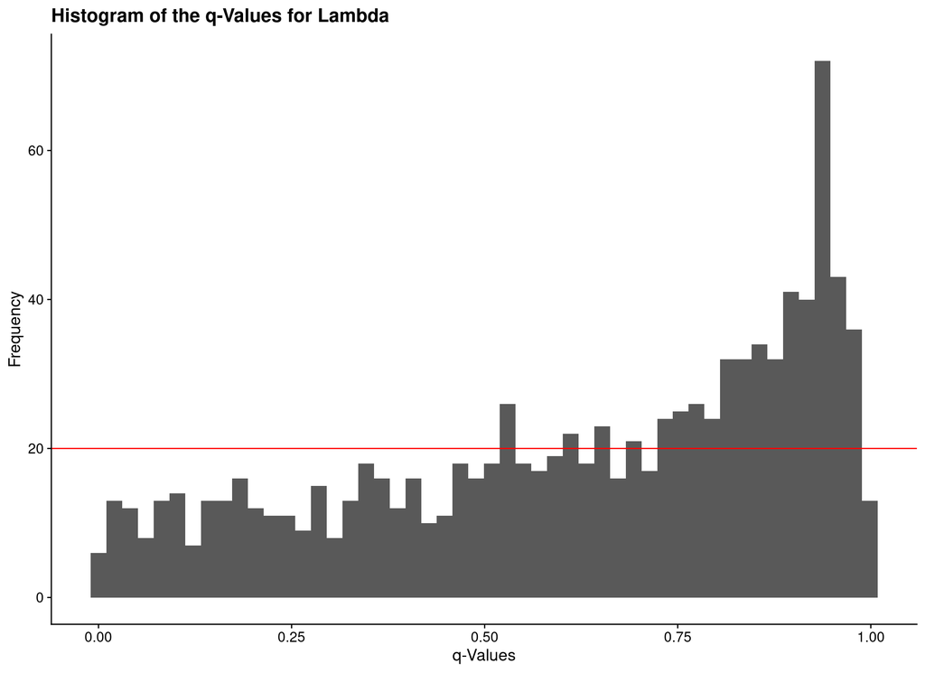

```r
pnbd_fixed2_valid_lst$lambda_qval_plot %>% plot()
```

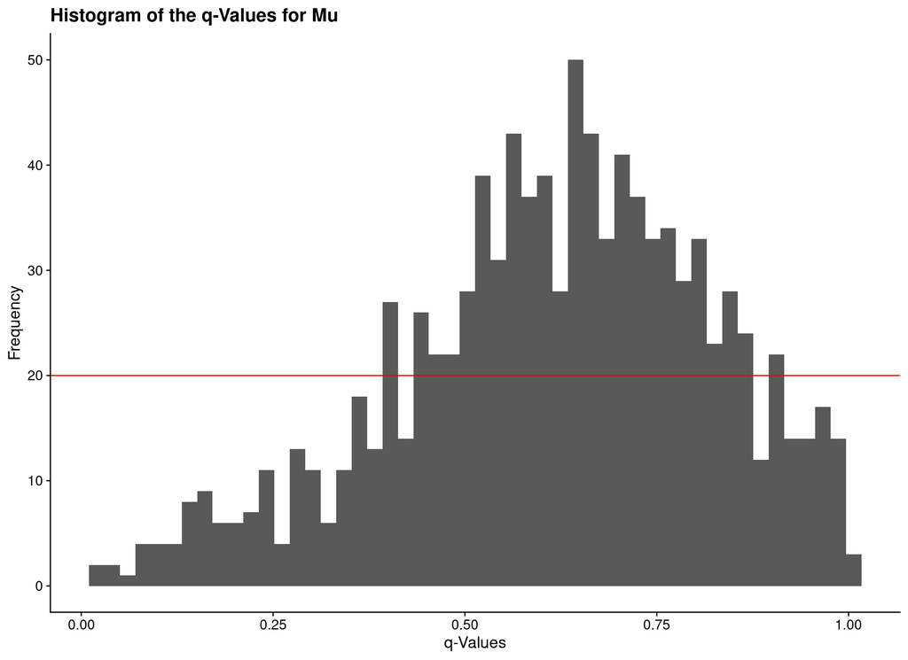

```r
pnbd_fixed2_valid_lst$mu_qval_plot %>% plot()
```

# 6 R Environment

```r
options(width = 120L)
```

```r
options(width = 80L)
```